# How to upload a Shiny app

Elgar Teo

2020-04-12

This tutorial will show you how to share your Shiny app by using the free Shiny app hosting service [shinyapps.io](https://www.shinyapps.io/).

## Setting up

First, create an account on shinyapps.io and log into the [dashboard](https://www.shinyapps.io/admin/#/login). Afterwards, click on *Account* on the sidebar and choose *Tokens*.

[figure not shown]

Click *Add Token* on the top right. A token will be generated in a split second and shown below:

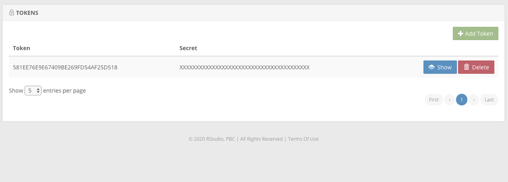

Click *Show* to view the token. You’ll see an R command containing the token and the secret. But note that the secret is hidden as `"secret='<SECRET>'"`. Click *Show secret* to reveal the secret:

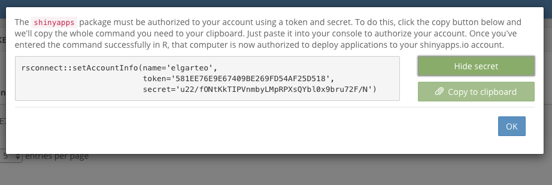

Afterwards, click *Copy to clipboard* and copy the R command.

[figure not shown]

Paste it in RStudio’s console and execute it. This will link up your shinyapps.io account with RStudio using the token and the secret automatically.

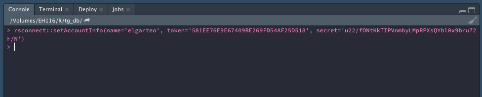

## Uploading the Shiny app

When your app is ready, click on the blue icon next the *Run App* button:

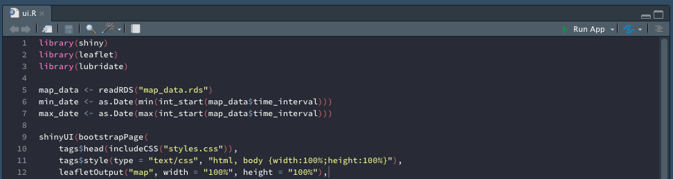

A popup dialog will show up. Please make sure all the files you used for your app are selected in the file list on the left. Your app should typically consists of a *ui.R*, a *server.R* and the .rds files containing the external data. You should also see your shinyapps.io account on the right. Pick a name for your app in the *Title* field.

[figure not shown]

If you are re-uploading an updated version, you should see your previouslay uploaded app name instead of the *Title* field:

[figure not shown]

If you don’t see a dialog like this, please repeat the set up process again. If you’re getting error message saying that your token is invalid, please generate a new token and try again.

Click *Publish* to upload your app. It’ll take a minute or two depending on the size of your app. You can check the upload progress (and error messages if any) in the Deploy panel at the bottom.

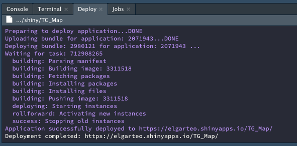

You should see the link of the uploaded app once it’s succesfully uploaded. If it fails, please send me the error messages via email.

*Note: The shinyapps.io token and secret shown in this tutorial is just for demonstration purposes and is invalid.*